TODO: #1 (arbitrary Bayes risk)

```python
import numpy as np

from matplotlib import pyplot as plt
from scipy.stats import norm
from tqdm.notebook import tqdm
```

# 1

In each of the following models, find the Bayes risk and the Bayes estimator, using squared error loss.

(a) $X \sim \text{Binomial}(n, p)$, $p \sim \text{Beta}(\alpha, \beta)$.

(b) $X \sim \text{Poisson}(\lambda)$, $\lambda \sim \text{Gamma}(\alpha, \beta)$.

(c) $X \sim N(\theta, \sigma^2)$ where $\sigma^2$ is known and $\theta \sim N(a, b^2)$.

*Solution*:

(a) Since we are using squared error loss, Theorem 12.8 says the Bayes estimator is the posterior mean.

The posterior is

\begin{align*} f(p \mid X=x) &\propto {n \choose x} p ^ x (1 - p) ^ {n - x} \frac{\Gamma(\alpha + \beta)}{\Gamma(\alpha)\Gamma(\beta)} p ^ {\alpha - 1}(1 - p) ^ {\beta - 1} \\ &= \propto p^{\alpha + x - 1} (1 - p) ^ {\beta + n - x - 1}. \end{align*}

Thus, $p \mid X \sim \text{Beta}(\alpha + x, \beta + n - x)$, which has mean $\frac{\alpha + x}{\alpha + \beta + n}$.

(b) We show in Chapter 11, #6(a) that $\lambda \mid X \sim \text{Gamma}\left(\alpha + x, \frac{\beta}{\beta + 1}\right)$, which has mean $\frac{(\alpha + x)\beta}{\beta + 1}$.

(c) We show in Chapter 11, #1 that $\theta \mid X \sim N(\bar{\theta}, \tau^2)$, where

$$\bar{\theta} = wX + (1-w)a,$$$$w = \frac{\frac{1}{\text{se}^2}}{\frac{1}{\text{se}^2} + \frac{1}{b^2}}, \frac{1}{\tau^2} = \frac{1}{\text{se}^2} + \frac{1}{b^2},$$

and $\text{se} = \sigma$ is the standard error of the MLE $X$. Hence the Bayes estimator is $\bar{\theta}$.

# 2

Let $X_1, \dots, X_n \sim N(\theta, \sigma^2)$ and suppose we estimate $\theta$ with loss function $L(\theta, \hat{\theta}) = (\theta - \hat{\theta})^2 / \sigma^2$. Show that $\bar{X}$ is admissable and minimax.

*Solution*:

Since the risk is constant:

\begin{align*} R(\theta, \bar{X}) &= \int \frac{(\theta - \bar{X})^2}{\sigma^2} f(x; \theta) \, dx \\ &= \frac{1}{\sigma^2}\left(\text{bias}^2_{\theta}(\bar{X}) + V_{\theta}(\bar{X}) \right) \\ &= \frac{1}{\sigma^2}\left(0 + \frac{\sigma^2}{n} \right) = \frac{1}{n}, \end{align*}

by Theorem 12.21, it suffices to show that $\hat{\theta}$ is admissable.

We know, from Theorem 12.20, that $\hat{\theta}$ is admissable under squared error loss. Let $R^*(\theta, \hat{\theta})$ be the risk under squared loss. Note that $R^*(\theta, \hat{\theta}) = \sigma^2 R(\theta, \hat{\theta})$. Suppose that $\hat{\theta}$ is inadmissable under $L$. Then, there exists a $\hat{\theta'}$ such that: $$R(\theta, \hat{\theta'}) \le R(\theta, \hat{\theta})\quad \text{for all } \theta$$ and $$R(\theta, \hat{\theta'}) < R(\theta, \hat{\theta})\quad \text{for at least one } \theta$$ But then $$R^*(\theta, \hat{\theta'}) = \sigma^2 R(\theta, \hat{\theta'}) \le \sigma^2 R(\theta, \hat{\theta}) = R^*(\theta, \hat{\theta}) \quad \text{for all } \theta$$ and $$R^*(\theta, \hat{\theta'}) = \sigma^2 R(\theta, \hat{\theta'}) < \sigma^2 R(\theta, \hat{\theta}) = R^*(\theta, \hat{\theta}) \quad \text{for at least one } \theta$$ a contradiction.

# 3

Let $\Theta = \{\theta_1,\dots,\theta_k\}$ be a finite parameter space. Prove that the posterior mode is the Bayes estimator under zero–one loss.

*Solution*:

By Theorem 12.7, the choice of $\hat{\theta}$ that minimizes the posterior risk is the Bayes estimator. The posterior risk is:

\begin{align*} r(\hat{\theta} \mid x) &= \int L(\theta, \hat{\theta}(x))f(\theta \mid x) \, d\theta \\ &= \sum_{i=1}^k \mathbb{1}_{\hat{\theta} \ne \theta_i} f(\theta_i \mid x) \end{align*}

which is minimized when choosing $\hat{\theta}$ to be the choice of $\theta_i$ that maximizes $f(\theta_i \mid x)$, i.e., the posterior mode.

# 4

Let $X_1, \dots, X_n$ be a sample from a distribution with variance $\sigma^2$. Consider estimators of the form $bS^2$ where $S^2$ is the sample variance. Let the loss function for estimating $\sigma^2$ be

$$L(\sigma^2, \hat{\sigma}^2) = \frac{\hat{\sigma}^2}{\sigma^2} - 1 - \log \left( \frac{\hat{\sigma}^2}{\sigma^2} \right).$$

Find the optimal value of $b$ that minimizes the risk for all $\sigma^2$.

*Solution*:

Computing the risk:

\begin{align*} R(\sigma^2, bS^2) &= \int L(\sigma^2, bS^2) f(x; \sigma^2) \, dx \\ &= \int \left[\frac{bS^2}{\sigma^2} - 1 - \log \left( \frac{bS^2}{\sigma^2} \right) \right] f(x; \sigma^2) \, dx \\ &= \frac{b}{\sigma^2}\mathbb{E}(S^2) - 1 - \log(b) - \mathbb{E}(\log(S^2)) - \mathbb{E}(\log(\sigma^2)) \\ &= b - 1 - \log(b) + C. \end{align*}

Thus, the derivative of the risk with respect to $b$ is $1 - \frac{1}{b}$. Equating with 0 yields the optimal value $b^* = 1$.

# 5

Let $X \sim \text{Binomial}(n, p)$ and suppose the loss function is

$$L(p, \hat{p}) = \left(1 - \frac{\hat{p}}{p}\right)^2$$

where $0 < p < 1$. Consider the estimator $\hat{p}(X) = 0$. This estimator falls outside the parameter space $(0, 1)$ but we will allow this. Show that $\hat{p}(X)$ is the unique, minimax rule.

*Solution*: The risk of an estimator $\hat{p}'$ is: \begin{align*} R(p, \hat{p}') &= \int \left(1 - \frac{\hat{p}'}{p}\right)^2 f(x, p) \, dx \\ &= \frac{1}{p^2} \int (p - \hat{p}')^2 f(x, p) \, dx \\ &= \frac{1}{p^2} \left(p^2 - 2p\mathbb{E}(\hat{p}') + \mathbb{E}\hat{p}'^2\right) \\ \end{align*}

Since the moments of $\hat{p}$ are 0, the risk of $\hat{p}$ is 1 for all $p$. To show that $\hat{p}$ is the unique minimax rule, we must show that for any other estimator, $\hat{p}'$, we can identify a $p$ such that the risk is strictly greater than 1. Assume $\hat{p}'$ is restricted to $(0,1)$. Let $a$ and $b$ be the first and second moments of $\hat{p}'$, respectively. Then $a, b \in (0, 1)$, and,

\begin{align*} R(p, \hat{p}') &= \frac{1}{p^2} \left(p^2 - 2pa + b\right) \\ &= 1 - \frac{2a}{p} + \frac{b}{p^2} \end{align*}

To make the risk greater than one, we ensure:

\begin{align*} \frac{b}{p^2} &\ge \frac{2a}{p} \\ \Rightarrow p \le \frac{b}{2a} \end{align*}

# 6

(Computer Experiment.) Compute the risk of the MLE and the James Stein estimator by simulation. Try various values of $n$ and various vectors $\theta$. Summarize your findings.

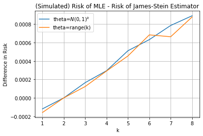

```python
n = 10000
k_max = 8
K = np.arange(1, k_max + 1, 1)

def loss(theta, theta_hat):
    return np.sum(np.power(theta - theta_hat, 2), axis=1)


thetas = [[np.random.normal(scale=1) for _ in range(k_max)],
          [k for k in range(k_max)]]


theta_names = ['$N(0,1)^k$', 'range(k)']

for theta, theta_name in zip(thetas, theta_names):
    mle_risks = []
    jse_risks = []
    for k in K:
        theta = [np.random.random() for _ in range(k)]

        X = norm.rvs(loc=theta[:k], scale=1, size = (n, k))

        mle = X
        jse = np.max(1 - (k - 2) / np.sum(np.power(X, 2)), 0) * X

        mle_risks.append(np.mean(loss(theta, mle)))
        jse_risks.append(np.mean(loss(theta, jse)))

    plt.plot(K, np.array(mle_risks) - np.array(jse_risks), label=f'theta={theta_name}')

plt.grid()
plt.title("(Simulated) Risk of MLE - Risk of James-Stein Estimator")
plt.xlabel("k")
plt.ylabel("Difference in Risk")
plt.legend()
plt.show()
```

For all vectors $\theta$ tested, the James Stein Estimator has larger risk than the MLE when $k = 1$, the same risk when $k=2$, and smaller risk for $k > 2$. The difference appears to be linear.